# 중국 히든젬 스크리닝 보고서 — Week 21

Alpha Hunter Hidden Gem Week 21 — 이번 주 조건 충족 종목 없음 (SEPA + 펀더멘탈 동시 통과 0건)

Author

Alpha Hunter × Chimera AI

Published

May 22, 2026

# 스크리닝 결론

**이번 주 추천 종목: 없음**

86개 중국 ADR/홍콩 종목을 스크리닝한 결과, **SEPA 트렌드 템플릿(8개 조건)과 펀더멘탈 필터를 동시에 통과한 신규 종목이 없습니다.**

> 알파헌터는 **좋은 회사가 아니라 좋은 주식**을 찾습니다. 펀더멘탈이 아무리 좋아도 기술적 추세가 뒷받침되지 않으면 추천하지 않습니다.

# 1 스크리닝 프로세스

## 1.1 STEP 1: 펀더멘탈 필터

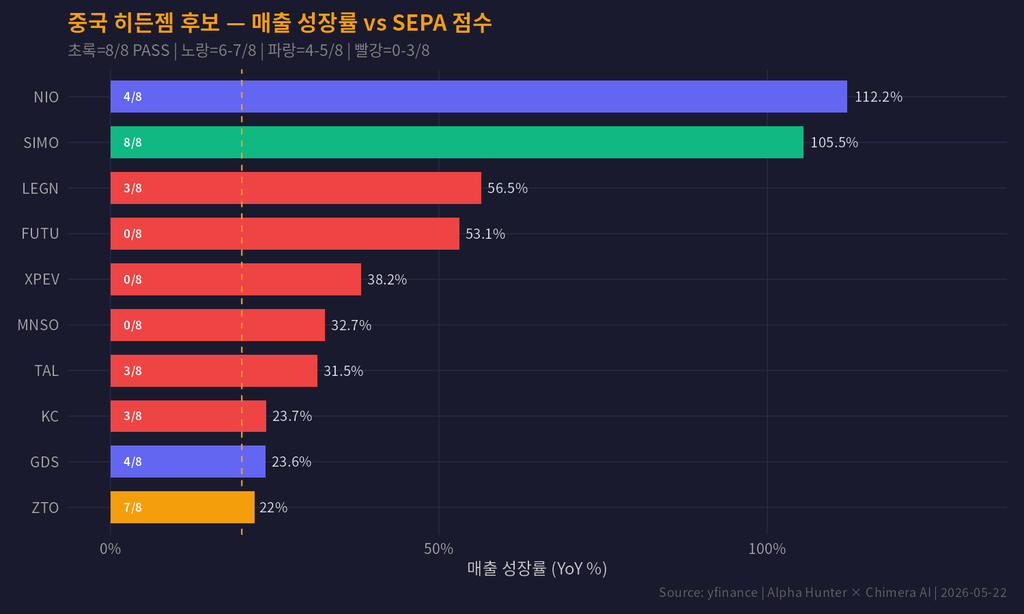

## 1.2 STEP 2: SEPA 트렌드 템플릿

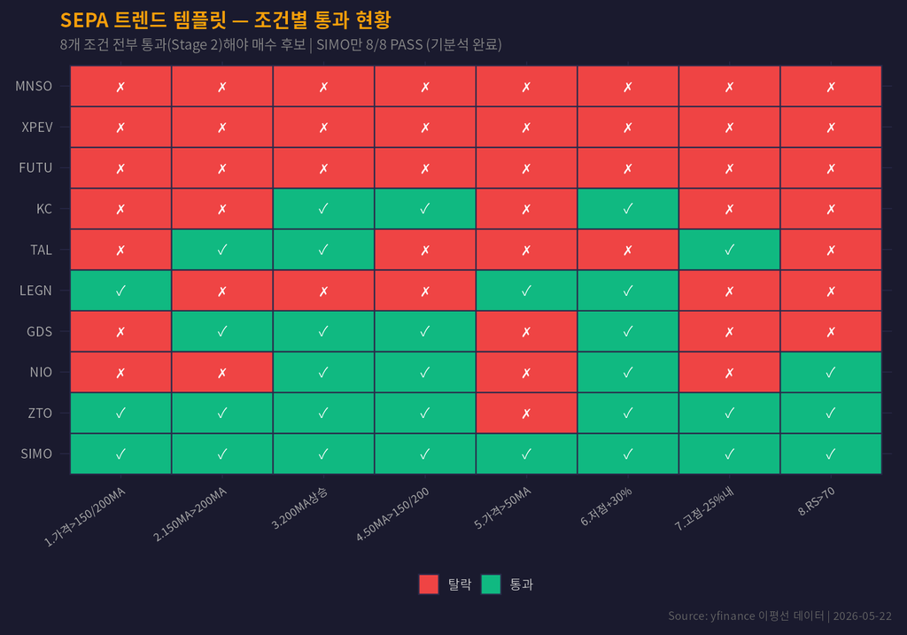

## 1.3 주요 탈락 사유

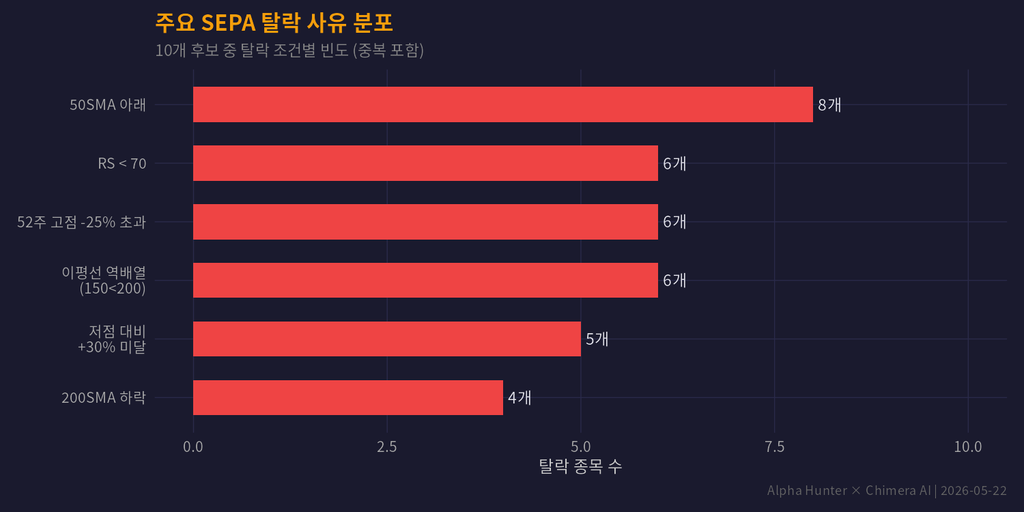

# 2 중국 시장 트렌드 분석

## 2.1 산업별 트렌드

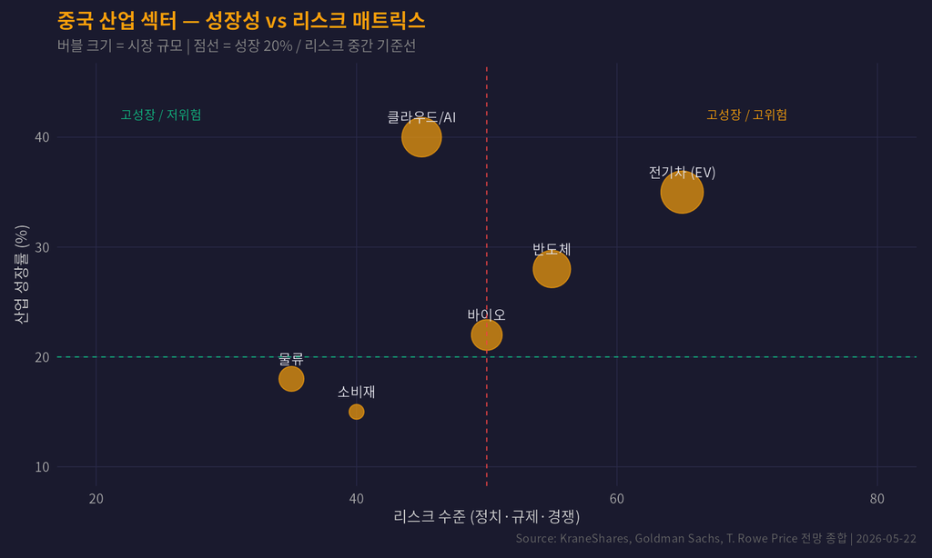

### 2.1.1 전기차 (EV)

- **BYD** 2025년 배터리 전기차 226만대 판매, 테슬라(164만대) 추월
- NIO 매출 +112% 급증하나 **영업적자 지속** (영업이익률 -1.2%)
- XPeng 매출 +38%이나 **주가 52주 고점 대비 -44%** — Stage 4 하락 추세
- 미·EU 관세 리스크: 중국산 EV에 100% 관세 (미국), 45.3% 관세 (EU)

### 2.1.2 반도체

- SMIC의 $5.8B 인수로 **파운드리 통합 가속** — 성숙 공정 글로벌 25%+ 점유
- **SIMO** (Week 19 추천) SEPA 8/8 유지 중, 주가 $263 (52주 고점 근처)
- 미국 수출 규제 강화: 첨단 장비·GPU 대중국 제한 지속

### 2.1.3 바이오

- Legend Biotech (LEGN) CAR-T 치료제 Carvykti 매출 +56% 성장
- 그러나 **주가 52주 고점 대비 -37%**, SEPA 3/8로 기술적 하락 추세
- 중국 바이오시밀러·혁신신약 글로벌 라이센싱 활발

## 2.2 정치 리스크: VIE 구조 + 미중 갈등

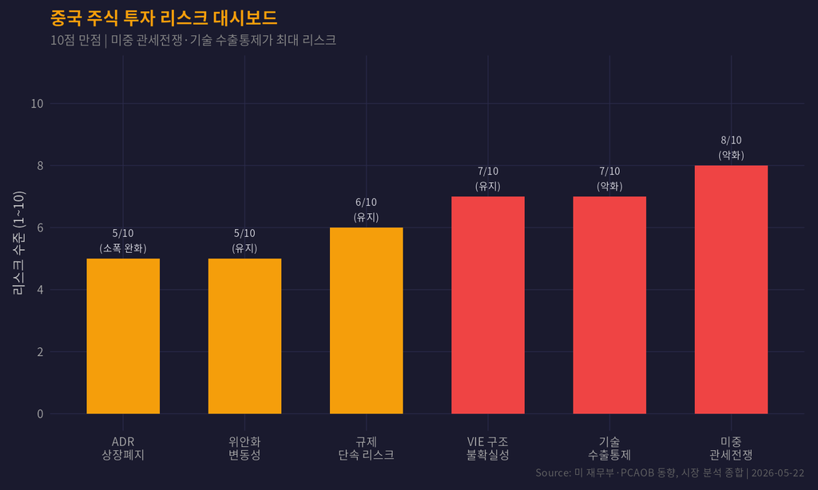

**핵심 리스크 요약:**

- **VIE 구조**: 286개 중국 ADR (시총 $1.1조) 중 상당수가 VIE 구조. 중국 정부의 VIE 인정 여부 불확실성 상존
- **ADR 상장폐지**: 미 재무장관 Bessent, ADR 상장폐지 가능성 시사. 다만 80%+가 홍콩 이중상장으로 리스크 관리 중
- **미중 관세전쟁**: 145% 상호관세 부과 상태. 비관세 조치(ADR 상장폐지)도 협상 카드로 활용 가능성
- **기술 수출통제**: 첨단 반도체 장비·AI 칩 대중국 수출 규제 강화 지속

# 3 근접 관찰 후보 (워치리스트)

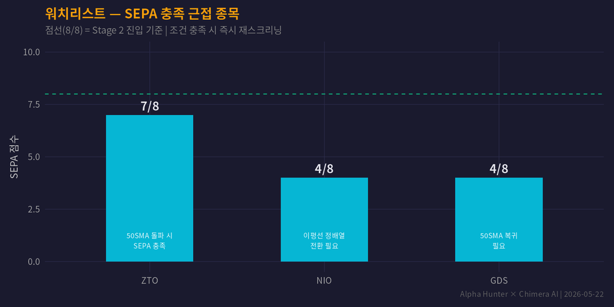

| 종목 | SEPA | 부족 조건 | 매출 성장 | 트리거 이벤트 |
| --- | --- | --- | --- | --- |
| **ZTO** | 7/8 | 50SMA($24.62) 돌파 필요 (현재 $22.83) | +22.0% | 50SMA 회복 시 Stage 2 진입 |
| **NIO** | 4/8 | 150/200SMA 아래, 이평선 역배열 | +112.2% | 매출 폭증이나 기술적 바닥 다지기 중 |
| **GDS** | 4/8 | 50/200SMA 아래, RS 약세 | +23.6% | AI 데이터센터 수요로 반등 가능성 |

# 4 결론 및 다음 주 전략

## 4.2 시장 환경 판단

- 미중 관세 갈등(145%)이 중국 ADR 전반에 하방 압력
- 다만 Goldman Sachs는 MSCI China +20% 전망 — **반등 시 기회 포착 필요**
- ZTO(7/8)가 50SMA 돌파 시 가장 먼저 Stage 2 진입 가능

## 4.3 다음 주 액션

- ZTO, NIO, GDS **이평선 위치 매일 모니터링**
- SIMO(기존 추천) SEPA 유지 여부 재점검
- 미중 무역 협상 진전 시 중국 ADR 일괄 반등 주시

**면책 조항**

이 프로젝트는 가상 투자 시뮬레이션 목적으로 작성되었습니다. 실제 투자 권유가 아닙니다.

*Alpha Hunter × Chimera AI — Week 21 중국 히든젬 스크리닝 보고서*